# BMIN503/EPID600 Project Template

Shaiza Sinha

```r
# packages
library(aod) #logistic regression
library(ggplot2)
library(gtsummary)
library(tidyverse)
library(ggpubr)
library(dplyr)
library(tableone)
```

### Overview

Give a brief a description of your project and its goal(s), what data you are using to complete it, and what two faculty/staff in different fields you have spoken to about your project with a brief summary of what you learned from each person. Include a link to your final project GitHub repository.

> TITLE: Philadelphia Landscape Assessment of Social-Demographic Characteristics for Receiving Adequate Prenatal Care in 2020-2021

> ABSTRACT: This project utilized data from the Center for Disease (CDC) WONDER Database 2016-2020 (expanded version), which follows an ad-hoc query system for *the analysis of public health data.* Using a multiple logistic regression model, the study aimed to identify the relationship between four selected maternal characteristics and receiving adequate prenatal care services with an emphasis on migrant populations in Philadelphia County, PA (n=18,084) and compare results state-wide performance in Pennsylvania (n=118,531).

> TEAM DETAILS: This project was discussed with the data team at the City of Philadelphia, Department of Public Health (PDPH) within the Maternal, Child, and Family Health Division (MCFH). Members of the data team, MH and AM, have been initialized for the team’s privacy. (Names can be found in the discussion comments of the Canvas Submission). The team consisted of a quantitative data analyst specialist (MP) MPH, CPH and the City’s chief medical officer MD, MPP.

> MH MPH, CPH was involved in assisting the development of the statistical approach. Meetings involved discussion of the best statistical process for the data set. MH recommended using multiple logistic regression and determining if prenatal services have been provided adequately through a dichotomous approach (Y/N to receiving adequate prenatal care) to simplify data interpretation. She is in the process of cleaning the Live Births data for Philadelphia (n=20,000) from this past year so we can apply the coding methods to a more recent and (potentially more) accurate dataset. The intended dataset would specifically consider undocumented immigrants determined via insurance status which is recorded within birth certificate forms in Philadelphia County. We are awaiting IRB approval in the meantime, the CDC dataset was used as a preliminary exercise to ensure the steps in code worked acurrately.

> AM MD, MPP acted in a supervisory role as chief medical officer to guide the selection of maternal social characteristics for assessment and identify the project’s social impact. There is currently very little understanding of migrant research and their respective health outcomes in Philadelphia, especially for maternal care..

> The coding material is intended to be used with a different dataset to utilize the findings to identify potential social barriers. The information from this project will ideally help confirm the need for a larger strategy proposal by acting as a *City Landscape Assessment* for developing a healthcare service delivery model for prenatal care for migrant individuals and/or undocumented immigrants.

> https://github.com/shaizas/BMIN503_Final_Project

### Introduction

Describe the problem addressed, its, and some background to motivate the problem. Explain why your problem is interdisciplinary, what fields can contribute to its understanding, and incorporate background related to what you learned from meeting with faculty/staff.

> Comprehensive prenatal care has been shown to lead to improved health outcomes for both mothers and newborns.1 If sought early in a birthing person’s pregnancy, prenatal care can be used as an effective preventative measure for adverse health outcomes, such as severe maternal morbidity and low neonatal birth weight.2,3 Services are typically established within the first six to eight weeks of pregnancy, following twelve to fifteen visits in total after the initial visit.4 The current model practiced within the United States recommends that patients visit monthly until twenty-eight weeks, bi-weekly until thirty-two weeks, and weekly until delivery.4 Visits are critical to promoting a safe delivery by effectively monitoring the patient’s progress and development of the fetus. Healthcare providers are responsible for providing supportive care through medical screenings, lab testing for birth anomalies, image testing, and education (parenting, pregnancy materials, infant feeding).2 Services often include psychosocial support to address substance use, resources for domestic violence, mental health services, avenues for financial aid, and nutritional needs.4

> The City of Philadelphia has a highly urban landscape, with individuals belonging to diverse social and cultural backgrounds that may hinder access to quality prenatal care. In 2020, only 52% of birthing persons sought care within the first trimester in Philadelphia, which is comparatively much lower than the national average of 77%.5,6 The Philadelphia Maternal Mortality Review Committee (MMRC) found that 32% of all pregnancy-associated deaths occurred in birthing persons who didn’t opt in for prenatal care or were too late (third trimester).6 Of these deaths, 69% of individuals, had multiple co-morbidities that would have been screened and identified appropriately had the patient attended regular prenatal visits.6 These statistics capture the challenges from potential barriers patients may face to receiving adequate maternal and child care in Philadelphia. Common barriers include financial constraints, transportation access, lifestyle limitations (childcare, paid time off from work), and overall distrust of the medical field stemming from perceived discrimination and cultural practice.7 Social indicators such as race, age, education levels, socio-economic status have shown to have associations with receiving adequate prenatal care, however nativity has never been explored in the literature for Philadelphia.

> Identifying currently underserved populations that are receiving inadequate access to prenatal services is critical for equitably promoting better maternal and child outcomes. However, there is very limited research in identifying potential social barriers migrant populations face in Philadelphia County.

> **This project aims to determine the relationship between maternal demographic characteristics for birthing persons, especially immigrant populations, to assess which demographic of individuals may be undeserved in receiving adequate prenatal care services.** *This project specifically used a multiple logistic regression approach to assess the social indicators of race, age, and education level, and maternal nativity (Born in the US vs. Born outside of the US) with receiving adequate prenatal care (Y/N: >=10 visits made during pregnancy)* For comparative interest, results were compared from a state to city point-of-view to highlight differences in trends– but not intended for the use of my capstone.

> Evaluations will require an intersectional approach for analysis. Biomedical informatics can be an effective tool for statistical analysis for identify the gravity of public health issues. The results can be helpful to many stakeholders within the maternal and child health sector, from community organizations to large-scale hospital systems. An improved understanding of prenatal care adequacy is critical for identifying barriers to eliminating current issues through robust program implementation.

> The findings of this project will potentially be incorporated into a larger strategy proposal for the City of Philadelphia, which aims to propose a series of recommendations that the Department of Public Health can modify for implementation in Philadelphia to improve antenatal services to undocumented residents through insurance status.

### Methods

Describe the data used and general methodological approach. Subsequently, incorporate full R code necessary to retrieve and clean data, and perform analysis. Be sure to include a description of code so that others (including your future self) can understand what you are doing and why.

> DATABASE DETAILS: Using a population-based design, the quantitative assessment utilized data from the CDC’S WONDER Database, which collects information on an ad-hoc basis for various public health variables and demographic characteristics. The newest dataset was drawn from the Natality online database, which is compiled of data primarily obtained from birth certificates issued from 2016 to 2020 (most updated version).

> The social indicators of race, age, education level, and maternal nativity (born in the US versus born outside of the US) were selected to determine if adequate prenatal care had been provided to Philadelphia birthing person populations in 2020-2021 using the Kotelchuck Index in a dichotomous format. According to the American College of Obstetricians and Gynecologists (ACOG), Adequate prenatal care is determined by two variables obtained from birth certificates which include when prenatal care was started and the number of prenatal visits until delivery. Typically, adequate care is achieved if a patient has completed 80% or roughly ten appointments. While the Kotelchuck Index cannot determine the quality of prenatal care or accurately be applied for high-risk pregnancies, it remains a commonly utilized method for determining if prenatal care services have been adequately provided.9 **Using the ACOG guidelines, adequate prenatal care was defined as if a patient had ten visits or more visits (visits>=10).**

> In this analysis, a multiple logistic regression was conducted using R Studio. Univariate analysis of each indicator was determined using logistic regression and chi-square for overall model fit. A multivariate logistic regression was then conducted to compute odd-ratio (OR) and 95% confidence intervals (CI). The code was assessed by a data team by the Philadelphia Department of Public Health and the University of Pennsylvania.

> Based on the selected social indicators, we first identified the 118,531 births that occurred in Pennsylvania and extrapolated births in Philadelphia County (n=18,084). We excluded birthing persons based on missing data. Maternal nativity was defined dichotomously based on whether the birthing person was US-Born or born outside of the US, including possessions. Race was categorized as White, Black or African American, Asian, or more than one Race. The Age groups were: 15-19, 20-24, 25-29, 30-34, 35-39, and 40-44, with ages 25-29 as the selected comparative group given the literature supports this age range typically has the lowest adverse health outcomes.8 Education followed the CDC’s eight levels of categories as follows 1: 8th grade or less, 2: 9th through 12th grade with no diploma, 3: High school graduate or GED Completed, 4: Some college credit but not a degree, 5: Associate Degree (AA, AS), 6: Bachelor’s degree (BA, AB, BS), 7: Master’s degree, 8: Doctorate or Professional degree. The following dataset would stratify education into four categories (1: less than high school, 2: High school and/or some college, 2: Bachelor’s and Associate degrees, 3: Higher education including Master’s, Doctorate, or Professional degrees).

> **Statistical Test: Logistic Regressions** Assumptions of Dataset: large N, no/few empty small cells,  
> *Dependent variable: (Assumptions Must be Dichotomous/Binary) Received adequate prenatal care (10 or more visits) (0=N/1=Y)* 1. 0: inadequate prenatal care (less than 10 visits) 1. 1: adequate prenatal care provided (equal to or more than 10 visits)

> *Independent Variables/Observed: can be categorical or continuous; Observed variables: race, age, education level* Population: Individuals who gave birth in 2020-2021 (Assessing US-Born vs. Born outside of the US/Migrant)

> CODING METHODS:

> CDC Wonder Data was provided in a .txt format and converted into .csv for easier uploading purposes and readability, the file was uploaded on github and can be accessed below

#Upload dataset into R

```r
cdcwonder <- read.csv(url("https://raw.githubusercontent.com/shaizas/BMIN503_Final_Project/master/Natality%2C%202020%20.csv"), header = TRUE)
```

#Data Frame Checks

```r
#list variables in the df
names(cdcwonder)
```

```
##  [1] "County.of.Residence"               "County.of.Residence.Code"
##  [3] "Mother.s.Single.Race.6"            "Mother.s.Single.Race.6.Code"
##  [5] "Age.of.Mother.9"                   "Age.of.Mother.9.Code"
##  [7] "Mother.s.Education"                "Mother.s.Education.Code"
##  [9] "Mother.s.Nativity"                 "Mother.s.Nativity.Code"
## [11] "Births"                            "Average.Number.of.Prenatal.Visits"
```

```r
#view first few lines of df
head(cdcwonder)
```

```
##   County.of.Residence County.of.Residence.Code Mother.s.Single.Race.6
## 1    Adams County, PA                    42001                  White
## 2    Adams County, PA                    42001                  White
## 3    Adams County, PA                    42001                  White
## 4    Adams County, PA                    42001                  White
## 5    Adams County, PA                    42001                  White
## 6    Adams County, PA                    42001                  White
##   Mother.s.Single.Race.6.Code Age.of.Mother.9 Age.of.Mother.9.Code
## 1                      2106-3     15-19 years                15-19
## 2                      2106-3     20-24 years                20-24
## 3                      2106-3     20-24 years                20-24
## 4                      2106-3     20-24 years                20-24
## 5                      2106-3     20-24 years                20-24
## 6                      2106-3     25-29 years                25-29
##                       Mother.s.Education Mother.s.Education.Code
```

[output cut: 20 more lines]

```r
#view structure of df
str(cdcwonder)
```

```
## 'data.frame':    1816 obs. of  12 variables:
##  $ County.of.Residence              : chr  "Adams County, PA" "Adams County, PA" "Adams County, PA" "Adams County, PA" ...
##  $ County.of.Residence.Code         : int  42001 42001 42001 42001 42001 42001 42001 42001 42001 42001 ...
##  $ Mother.s.Single.Race.6           : chr  "White" "White" "White" "White" ...
##  $ Mother.s.Single.Race.6.Code      : chr  "2106-3" "2106-3" "2106-3" "2106-3" ...
##  $ Age.of.Mother.9                  : chr  "15-19 years" "20-24 years" "20-24 years" "20-24 years" ...
##  $ Age.of.Mother.9.Code             : chr  "15-19" "20-24" "20-24" "20-24" ...
##  $ Mother.s.Education               : chr  "9th through 12th grade with no diploma" "9th through 12th grade with no diploma" "High school graduate or GED completed" "Some college credit, but not a degree" ...
##  $ Mother.s.Education.Code          : chr  "2" "2" "3" "4" ...
##  $ Mother.s.Nativity                : chr  "Born in the U.S. (50 US States)" "Born in the U.S. (50 US States)" "Born in the U.S. (50 US States)" "Born in the U.S. (50 US States)" ...
##  $ Mother.s.Nativity.Code           : int  1 1 1 1 1 1 1 1 1 1 ...
##  $ Births                           : int  10 16 64 36 12 16 86 60 45 75 ...
##  $ Average.Number.of.Prenatal.Visits: num  11.7 10.5 12.1 11.8 11.5 ...
```

```r
#summary of data
summary (cdcwonder)
```

```
##  County.of.Residence County.of.Residence.Code Mother.s.Single.Race.6
##  Length:1816         Min.   :42001            Length:1816
##  Class :character    1st Qu.:42029            Class :character
##  Mode  :character    Median :42071            Mode  :character
##                      Mean   :42100
##                      3rd Qu.:42095
##                      Max.   :42999
##  Mother.s.Single.Race.6.Code Age.of.Mother.9    Age.of.Mother.9.Code
##  Length:1816                 Length:1816        Length:1816
##  Class :character            Class :character   Class :character
##  Mode  :character            Mode  :character   Mode  :character
##
##
##
##  Mother.s.Education Mother.s.Education.Code Mother.s.Nativity
##  Length:1816        Length:1816             Length:1816
##  Class :character   Class :character        Class :character
##  Mode  :character   Mode  :character        Mode  :character
##
##
##
##  Mother.s.Nativity.Code     Births        Average.Number.of.Prenatal.Visits
##  Min.   :1.000          Min.   :  10.00   Min.   : 3.46
##  1st Qu.:1.000          1st Qu.:  16.00   1st Qu.:10.09
##  Median :1.000          Median :  28.00   Median :11.36
##  Mean   :1.277          Mean   :  65.48   Mean   :11.24
##  3rd Qu.:2.000          3rd Qu.:  64.00   3rd Qu.:12.37
##  Max.   :3.000          Max.   :1560.00   Max.   :18.45
```

```r
#SD of variables
sapply(cdcwonder,sd)
```

```
##               County.of.Residence          County.of.Residence.Code
##                                NA                       190.3002734
##            Mother.s.Single.Race.6       Mother.s.Single.Race.6.Code
##                                NA                                NA
##                   Age.of.Mother.9              Age.of.Mother.9.Code
##                                NA                                NA
##                Mother.s.Education           Mother.s.Education.Code
##                                NA                                NA
##                 Mother.s.Nativity            Mother.s.Nativity.Code
##                                NA                         0.4561655
##                            Births Average.Number.of.Prenatal.Visits
##                       120.5215698                         2.0310442
```

#Cleaning Data

```r
#The CDC aggregates data based on social characteristics, to get the data in it's most raw form we must uncount the births column to get a raw count of all PA and Philadelphia births.
library(dplyr)
cdcwonder <- tidyr::uncount(cdcwonder, Births)


#Rename Variables
cdcwonder <- dplyr::rename(cdcwonder, county = County.of.Residence,
                           age = Age.of.Mother.9.Code,
                           race = Mother.s.Single.Race.6,
                           countycode = County.of.Residence.Code, education = Mother.s.Education.Code, prenatal = Average.Number.of.Prenatal.Visits, maternalnativity=Mother.s.Nativity.Code)  %>%
filter(maternalnativity == 1 | maternalnativity ==2 ) %>% #remove value 3 which codes for unknown
filter(education %in%  c("1", "2", "3","4","5","6", "7", "8")) #to remove unk value which codes for unknown

head(cdcwonder)
```

```
##             county countycode  race Mother.s.Single.Race.6.Code Age.of.Mother.9
## 1 Adams County, PA      42001 White                      2106-3     15-19 years
## 2 Adams County, PA      42001 White                      2106-3     15-19 years
## 3 Adams County, PA      42001 White                      2106-3     15-19 years
## 4 Adams County, PA      42001 White                      2106-3     15-19 years
## 5 Adams County, PA      42001 White                      2106-3     15-19 years
## 6 Adams County, PA      42001 White                      2106-3     15-19 years
##     age                     Mother.s.Education education
## 1 15-19 9th through 12th grade with no diploma         2
## 2 15-19 9th through 12th grade with no diploma         2
## 3 15-19 9th through 12th grade with no diploma         2
## 4 15-19 9th through 12th grade with no diploma         2
## 5 15-19 9th through 12th grade with no diploma         2
## 6 15-19 9th through 12th grade with no diploma         2
##                 Mother.s.Nativity maternalnativity prenatal
## 1 Born in the U.S. (50 US States)                1     11.7
## 2 Born in the U.S. (50 US States)                1     11.7
## 3 Born in the U.S. (50 US States)                1     11.7
## 4 Born in the U.S. (50 US States)                1     11.7
## 5 Born in the U.S. (50 US States)                1     11.7
## 6 Born in the U.S. (50 US States)                1     11.7
```

```r
#Assess sample size for Philadelphia Births in 2020
cdcwonder %>%
  filter( county == "Philadelphia County, PA") %>%
  dplyr::summarise(n())
```

```
##     n()
## 1 18084
```

> 18084 recorded births with values of selected social indicators can be found for Philadelphia County in this data set

```r
#create a clean df for PA
clean_PA <- cdcwonder %>%
    drop_na(prenatal,maternalnativity,race, age,education) %>% #drop any NA values
  select(prenatal, maternalnativity, race, age, education) %>% #selecting needed variables and social variables
mutate(prenatal=cut(prenatal,breaks=c(0,10,30),labels=c("0", "1"))) #Converting into dichotomous outcome variable for logistic regression #0:Inadequate Prenatal Care (less than 10 visits), 1: Adequate Prenatal Care (more than or equal to 10 visits)

head(clean_PA)
```

```
##   prenatal maternalnativity  race   age education
## 1        1                1 White 15-19         2
## 2        1                1 White 15-19         2
## 3        1                1 White 15-19         2
## 4        1                1 White 15-19         2
## 5        1                1 White 15-19         2
## 6        1                1 White 15-19         2
```

```r
#create a clean df for Philly
clean_philly <- cdcwonder %>%
    filter(countycode == 42101) %>% # filtering for all Philadelphia births
    drop_na(prenatal,maternalnativity,race,age,education) %>% #drop any NA values
  select(prenatal, maternalnativity, race, age, education) %>% #selecting needed variables and social variables
  mutate(prenatal=cut(prenatal,breaks=c(0,10,30),labels=c("0", "1")))  #Converting into dichotomous outcome variable for logistic regression #0:Inadequate Prenatal Care (less than 10 visits), 1: Adequate Prenatal Care (more than or equal to 10 visits)
```

```r
#check to make sure no NA values: Looks good --> changed to false to avoid table
is.na.data.frame(clean_philly)
is.na.data.frame(clean_PA)
```

#Check Crosstabs: Assess Adequate Prenatal Care Distribution in PA and in Philadelphia

```r
#Create a contingency table of categorical predictors that are binary to make sure that there isn't a cell that is 0 --> Important check for logistic regressions (LRs)
#if a table has multiple zeros, the df is not suitable for a LR
#checking for confounders

#PA
xtabs(~clean_PA$maternalnativity + race, data=clean_PA)
```

```
##                          race
## clean_PA$maternalnativity Asian Black or African American More than one race
##                         1   543                     14681               1489
##                         2  3552                      2402                  0
##                          race
## clean_PA$maternalnativity White
##                         1 88304
##                         2  7560
```

```r
xtabs(~clean_PA$maternalnativity + education, data=clean_PA)
```

```
##                          education
## clean_PA$maternalnativity     1     2     3     4     5     6     7     8
##                         1  3114  6758 26762 16731  9038 25234 14040  3340
##                         2   559  1070  3878  1810   617  3290  1690   600
```

```r
xtabs(~clean_PA$maternalnativity + age, data=clean_PA)
```

```
##                          age
## clean_PA$maternalnativity 15-19 20-24 25-29 30-34 35-39 40-44
##                         1  3297 16710 29825 36029 16917  2239
##                         2   273  1874  3618  4810  2663   276
```

```r
#Philly
xtabs(~clean_philly$maternalnativity + race, data=clean_philly)
```

```
##                              race
## clean_philly$maternalnativity Asian Black or African American
##                             1   288                      7157
##                             2  1028                      1175
##                              race
## clean_philly$maternalnativity More than one race White
##                             1                395  5750
##                             2                  0  2291
```

```r
xtabs(~clean_philly$maternalnativity + education, data=clean_philly)
```

```
##                              education
## clean_philly$maternalnativity    1    2    3    4    5    6    7    8
##                             1   21 1240 4419 2620  763 2402 1503  622
##                             2  350  534 1221  668  290  877  347  207
```

```r
xtabs(~clean_philly$maternalnativity + age, data=clean_philly)
```

```
##                              age
## clean_philly$maternalnativity 15-19 20-24 25-29 30-34 35-39 40-44
##                             1   730  2449  3468  4373  2150   420
##                             2   139   675  1177  1439   883   181
```

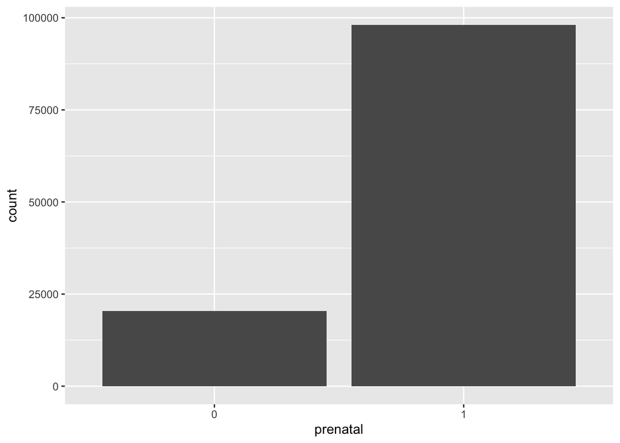

```r
#Assess prenatal distribution in PA
ggplot(data=clean_PA, aes(x=prenatal)) +
    geom_bar()
```

```r
summary(clean_PA$prenatal)
```

```
##     0     1
## 20443 98088
```

```r
summary(clean_PA)
```

```
##  prenatal  maternalnativity     race               age
##  0:20443   Min.   :1.000    Length:118531      Length:118531
##  1:98088   1st Qu.:1.000    Class :character   Class :character
##            Median :1.000    Mode  :character   Mode  :character
##            Mean   :1.114
##            3rd Qu.:1.000
##            Max.   :2.000
##   education
##  Length:118531
##  Class :character
##  Mode  :character
##
##
##
```

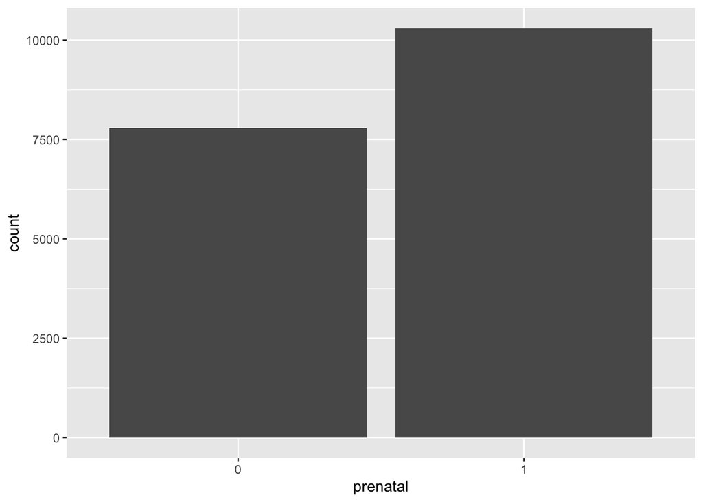

```r
#Assess prenatal distribution in Philly
ggplot(data=clean_philly, aes(x=prenatal)) +
    geom_bar()
```

```r
summary(clean_philly$prenatal)
```

```
##     0     1
##  7783 10301
```

```r
summary(clean_philly)
```

```
##  prenatal  maternalnativity     race               age
##  0: 7783   Min.   :1.000    Length:18084       Length:18084
##  1:10301   1st Qu.:1.000    Class :character   Class :character
##            Median :1.000    Mode  :character   Mode  :character
##            Mean   :1.249
##            3rd Qu.:1.000
##            Max.   :2.000
##   education
##  Length:18084
##  Class :character
##  Mode  :character
##
##
##
```

#Check Assumptions

```r
#Education: convert race to a factor to treat as categorical
clean_PA$education <- factor(clean_PA$education)
clean_philly$education <- factor(clean_philly$education)

#Age: convert age to a factor to treat as categorical
#Reorder age such that 25-29 is the comparative group, not 15-19 because the literature supports that individuals aged 25-29 tend to have the best maternal health outcomes in comparison to other age groups

clean_PA$age <- factor(clean_PA$age, levels = c('25-29','15-19','20-24', '30-34','35-39', '40-44'))
clean_philly$age <- factor(clean_philly$age, levels = c('25-29','15-19','20-24', '30-34','35-39', '40-44'))

#Race:convert race to a factor to treat as categorical
#Reorder race such that white is the comparative group, not Asian because the literature supports that White demographics receive more comprehensive prenatal care

clean_PA$race <- factor(clean_PA$race, levels = c('White','Asian', 'Black or African American', "More than one race"))
clean_philly$race <- factor(clean_philly$race, levels = c('White','Asian', 'Black or African American', "More than one race"))

#check relevel of factors
levels(clean_PA$age)
```

```
## [1] "25-29" "15-19" "20-24" "30-34" "35-39" "40-44"
```

```r
levels(clean_philly$age)
```

```
## [1] "25-29" "15-19" "20-24" "30-34" "35-39" "40-44"
```

```r
levels(clean_PA$race)
```

```
## [1] "White"                     "Asian"
## [3] "Black or African American" "More than one race"
```

```r
levels(clean_philly$race)
```

```
## [1] "White"                     "Asian"
## [3] "Black or African American" "More than one race"
```